# Lab 13: Environmental Predictors of Biosynthetic Gene Cluster Potential in Soil Microbial Communities

Author

Fiona Hanley

## This lab was generated entirely through the use of AI.

# Introduction

Microbial secondary metabolites play a central role in human health and medicine, forming the basis of many antibiotics, anticancer agents, immunosuppressants, and signaling molecules. The genes responsible for producing these compounds are typically organized into **biosynthetic gene clusters (BGCs)**—co-localized sets of genes that collectively encode complex metabolic pathways. While BGCs have been extensively studied in cultured microbes and clinical isolates, far less is known about how biosynthetic potential is distributed across natural environments or how environmental conditions shape microbial investment in secondary metabolism. Soils represent one of the most microbially diverse ecosystems on Earth and are a major reservoir of natural products with pharmaceutical relevance. In this study, we leverage metagenome-assembled genomes (MAGs) from the National Ecological Observatory Network (NEON), combined with associated soil chemistry and environmental metadata, to investigate how environmental factors predict community-level biosynthetic potential. Because direct BGC annotation requires complete genome sequences that are not always available, we employ a multi-proxy framework that integrates taxonomic identity, genome architectural properties, and hybrid metrics to infer biosynthetic capacity across environmental gradients.

# Load packages and data

```r
library(tidyverse)
library(lme4)
library(broom.mixed)
library(vegan)
```

```r
soilMAGs <- read_csv("NEON_soilMAGs_soilChem.csv")
```

# Renaming columns

```r
bgc_data <- soilMAGs %>%
  select(
    site = site,
    site_ID = site_ID,
    subplot = subplot,
    horizon = layer,
    phylum = phylum,
    genus = genus,
    genome_size_bp = total_number_of_bases,
    completeness = bin_completeness,
    contamination = bin_contamination,
    soil_pH = soilInWaterpH,
    soil_pH_CaCl = soilInCaClpH
  )
```

# Proxy 1: taxonomy-based BGC potential

To estimate biosynthetic gene cluster (BGC) potential based on evolutionary lineage, we assigned each MAG an expected BGC richness value using broad, literature-supported trends across bacterial phyla. Lineages known to be enriched in secondary metabolism, such as Actinobacteria and Firmicutes, were assigned higher proxy values, while lineages typically associated with streamlined genomes were assigned lower values. This taxonomy-based proxy captures lineage-level constraints on biosynthetic capacity without requiring direct genome sequence analysis.

```r
bgc_data <- bgc_data %>%
  mutate(
    bgc_taxonomy_proxy = case_when(
      phylum == "Actinobacteria" ~ 10,
      phylum == "Firmicutes" ~ 6,
      phylum == "Proteobacteria" ~ 3,
      phylum == "Bacteroidota" ~ 2,
      TRUE ~ 1
    )
  )
```

# Proxy 2: Genome-property-based BGC proxy

Because biosynthetic gene clusters are large, energetically costly genomic features, we used genome size as a proxy for overall metabolic and biosynthetic capacity. Genome completeness was included to account for variation in MAG assembly quality and the likelihood of capturing full metabolic pathways. These variables were standardized and combined into a continuous genome-property–based proxy representing the relative capacity of each MAG to encode complex secondary metabolism independent of taxonomic identity.

```r
bgc_data <- bgc_data %>%
  mutate(
    genome_size_mb = genome_size_bp / 1e6,
    bgc_genome_proxy =
      scale(genome_size_mb)[,1] +
      scale(completeness)[,1]
  )
```

# Proxy 3: Hybrid proxy (taxonomy x genome size)

To integrate lineage-level expectations with genome-specific investment, we constructed a hybrid BGC proxy by scaling the taxonomy-based BGC estimates by genome size. This hybrid metric captures within-lineage variation in genome expansion and provides a more nuanced estimate of biosynthetic potential, reflecting both evolutionary history and genome architecture.

```r
bgc_data <- bgc_data %>%
  mutate(
    bgc_hybrid_proxy = bgc_taxonomy_proxy * genome_size_mb
  )

bgc_data
```

```
# A tibble: 5,573 × 15
   site         site_ID subplot horizon phylum genus genome_size_bp completeness
   <chr>        <chr>   <chr>   <chr>   <chr>  <chr>          <dbl>        <dbl>
 1 Caribou-Pok… BONA    001     O       Acido… Sulf…        6486507         95.6
 2 Caribou-Pok… BONA    001     O       Actin… Pals…        3237739         94.7
 3 Caribou-Pok… BONA    001     O       Actin… Pals…        2712910         51.8
 4 Caribou-Pok… BONA    001     O       Acido… Sulf…        2720369         60.8
 5 Caribou-Pok… BONA    001     O       Acido… Pals…        3539081         81.5
 6 Caribou-Pok… BONA    001     O       Acido… Sulf…        3957793         88.1
 7 Caribou-Pok… BONA    001     O       Actin… Pals…        6054409         77.2
 8 Caribou-Pok… BONA    001     O       Pseud… Bog-…        2329620         66.3
 9 Caribou-Pok… BONA    001     O       Acido… Pals…        4300045         66.1
10 Caribou-Pok… BONA    001     O       Acido… QIAJ…        4009333         66.9
# ℹ 5,563 more rows
# ℹ 7 more variables: contamination <dbl>, soil_pH <dbl>, soil_pH_CaCl <dbl>,
#   bgc_taxonomy_proxy <dbl>, genome_size_mb <dbl>, bgc_genome_proxy <dbl>,
#   bgc_hybrid_proxy <dbl>
```

# Aggregate proxies by environmental sample

```r
bgc_env <- bgc_data %>%
  group_by(site, subplot, horizon) %>%
  summarise(
    taxonomic_BGC = sum(bgc_taxonomy_proxy, na.rm = TRUE),
    genome_BGC = sum(bgc_genome_proxy, na.rm = TRUE),
    hybrid_BGC = sum(bgc_hybrid_proxy, na.rm = TRUE),
    mean_pH = mean(soil_pH, na.rm = TRUE),
    .groups = "drop"
  )

bgc_env
```

```
# A tibble: 255 × 7
   site              subplot horizon taxonomic_BGC genome_BGC hybrid_BGC mean_pH
   <chr>             <chr>   <chr>           <dbl>      <dbl>      <dbl>   <dbl>
 1 Caribou-Poker Cr… 001     O                  33     -1.28       116.     3.99
 2 Caribou-Poker Cr… 002     O                  34     12.4        122.     4.35
 3 Caribou-Poker Cr… 004     O                  41     22.8        146.     3.69
 4 Caribou-Poker Cr… 006     O                  33      6.88       108.     4.05
 5 Caribou-Poker Cr… 009     O                  19      7.51        68.1    4.08
 6 Caribou-Poker Cr… 013     O                  32    -14.9         99.0    3.97
 7 Caribou-Poker Cr… 070     O                  13      7.22        50.6    4.28
 8 Caribou-Poker Cr… 071     O                  21      1.25        71.4    4.20
 9 Caribou-Poker Cr… 080     O                  34     12.8        134.     3.95
10 Caribou-Poker Cr… 084     O                  14     -0.202       50.7    5.00
# ℹ 245 more rows
```

# Environmental models

To assess environmental predictors of biosynthetic potential, we fit linear mixed-effects models with each BGC proxy as a response variable. Soil pH and soil layer were included as fixed effects, while site was included as a random effect to account for spatial non-independence among samples. Identical model structures were applied across all proxy definitions to allow direct comparison of environmental effect strength and direction.

```r
library(lme4)

mod_tax <- lmer(taxonomic_BGC ~ mean_pH + horizon + (1 | site), data = bgc_env)
mod_gen <- lmer(genome_BGC ~ mean_pH + horizon + (1 | site), data = bgc_env)
mod_hyb <- lmer(hybrid_BGC ~ mean_pH + horizon + (1 | site), data = bgc_env)

mod_tax
```

```
Linear mixed model fit by REML ['lmerMod']
Formula: taxonomic_BGC ~ mean_pH + horizon + (1 | site)
   Data: bgc_env
REML criterion at convergence: 2079.111
Random effects:
 Groups   Name        Std.Dev.
 site     (Intercept)  8.199
 Residual             13.692
Number of obs: 254, groups:  site, 31
Fixed Effects:
(Intercept)      mean_pH     horizonO
     45.242       -4.318        3.909
```

```r
mod_gen
```

```
Linear mixed model fit by REML ['lmerMod']
Formula: genome_BGC ~ mean_pH + horizon + (1 | site)
   Data: bgc_env
REML criterion at convergence: 2203.477
Random effects:
 Groups   Name        Std.Dev.
 site     (Intercept)  9.227
 Residual             17.739
Number of obs: 254, groups:  site, 31
Fixed Effects:
(Intercept)      mean_pH     horizonO
     33.919       -6.361        5.958
```

```r
mod_hyb
```

```
Linear mixed model fit by REML ['lmerMod']
Formula: hybrid_BGC ~ mean_pH + horizon + (1 | site)
   Data: bgc_env
REML criterion at convergence: 2768.472
Random effects:
 Groups   Name        Std.Dev.
 site     (Intercept) 33.16
 Residual             53.94
Number of obs: 254, groups:  site, 31
Fixed Effects:
(Intercept)      mean_pH     horizonO
     185.48       -20.78        17.34
```

# Compare results across proxies

Model coefficients from each proxy-specific analysis were extracted and compared to evaluate the consistency of environmental effects across proxy definitions. Concordant effect directions and magnitudes across independent proxies were interpreted as robust signals of environmental control on biosynthetic potential, while discrepancies among proxies provided insight into the sensitivity of inference to underlying biological assumptions.

```r
library(broom.mixed)

bind_rows(
  tidy(mod_tax) %>% mutate(proxy = "Taxonomy"),
  tidy(mod_gen) %>% mutate(proxy = "Genome"),
  tidy(mod_hyb) %>% mutate(proxy = "Hybrid")
)
```

```
# A tibble: 15 × 7
   effect   group    term            estimate std.error statistic proxy
   <chr>    <chr>    <chr>              <dbl>     <dbl>     <dbl> <chr>
 1 fixed    <NA>     (Intercept)        45.2       7.57      5.98 Taxonomy
 2 fixed    <NA>     mean_pH            -4.32      1.23     -3.52 Taxonomy
 3 fixed    <NA>     horizonO            3.91      3.00      1.30 Taxonomy
 4 ran_pars site     sd__(Intercept)     8.20     NA        NA    Taxonomy
 5 ran_pars Residual sd__Observation    13.7      NA        NA    Taxonomy
 6 fixed    <NA>     (Intercept)        33.9       9.29      3.65 Genome
 7 fixed    <NA>     mean_pH            -6.36      1.51     -4.22 Genome
 8 fixed    <NA>     horizonO            5.96      3.80      1.57 Genome
 9 ran_pars site     sd__(Intercept)     9.23     NA        NA    Genome
10 ran_pars Residual sd__Observation    17.7      NA        NA    Genome
11 fixed    <NA>     (Intercept)       185.       30.1       6.16 Hybrid
12 fixed    <NA>     mean_pH           -20.8       4.88     -4.25 Hybrid
13 fixed    <NA>     horizonO           17.3      11.9       1.46 Hybrid
14 ran_pars site     sd__(Intercept)    33.2      NA        NA    Hybrid
15 ran_pars Residual sd__Observation    53.9      NA        NA    Hybrid
```

# Cross proxy agreement

To quantify agreement among BGC proxy metrics, we calculated correlations between taxonomy-based, genome-based, and hybrid estimates of biosynthetic potential at the environmental sample level. This analysis assesses whether different proxy approaches identify similar biosynthetic “hotspots” and helps distinguish generalizable ecological patterns from proxy-specific artifacts.

```r
bgc_env %>%
  select(taxonomic_BGC, genome_BGC, hybrid_BGC) %>%
  cor(use = "pairwise.complete.obs")
```

```
              taxonomic_BGC genome_BGC hybrid_BGC
taxonomic_BGC     1.0000000  0.5936914  0.9611310
genome_BGC        0.5936914  1.0000000  0.7601476
hybrid_BGC        0.9611310  0.7601476  1.0000000
```

# Visualization of proxy relationships

Relationships among BGC proxies were visualized using scatterplots to illustrate agreement and divergence across methods. Visualization provides an intuitive assessment of methodological robustness and highlights samples or environments where biosynthetic potential estimates differ depending on proxy definition.

### Scatterplot 1: Taxonomy-based vs genome-based proxy

#### Do BGC-rich lineages also tend to have genome architectures consistent with high biosynthetic capacity?

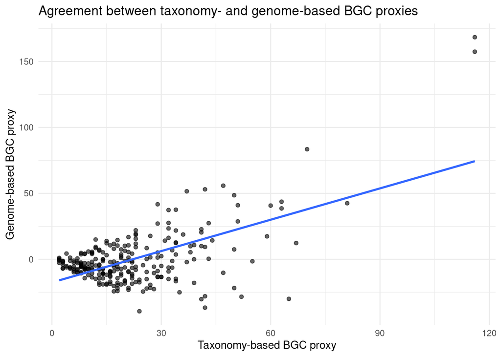

```r
ggplot(bgc_env, aes(x = taxonomic_BGC, y = genome_BGC)) +
  geom_point(alpha = 0.6) +
  geom_smooth(method = "lm", se = FALSE) +
  theme_minimal() +
  labs(
    x = "Taxonomy-based BGC proxy",
    y = "Genome-based BGC proxy",
    title = "Agreement between taxonomy- and genome-based BGC proxies"
  )
```

### Scatterplot 2: Taxonomy-based vs hybrid proxy

#### Within the same evolutionary groups, does genome expansion matter?

- Genome size does not vary much within lineages
- Hybrid proxy closely tracks taxonomy alone

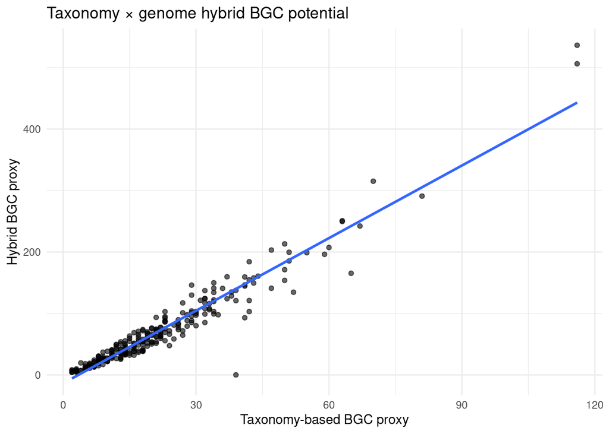

```r
ggplot(bgc_env, aes(x = taxonomic_BGC, y = hybrid_BGC)) +
  geom_point(alpha = 0.6) +
  geom_smooth(method = "lm", se = FALSE) +
  theme_minimal() +
  labs(
    x = "Taxonomy-based BGC proxy",
    y = "Hybrid BGC proxy",
    title = "Taxonomy × genome hybrid BGC potential"
  )
```